# 공간통계를 위한 데이터 사이언스

육각형(Hexagon) 지도

[Tidyverse Korea](https://www.facebook.com/groups/tidyverse/)

2020-04-03

# 1 2D 히스토그램: `hexbin`

`hexbin` 팩키지는 `Hexagon Binning`을 통해 2차원 평면에 히스토그램을 육각형 도형으로 표현하는 시각화 도구로 매우 큰 데이터를 시각화하는데 유용하다. 기본 알고리즘은 다음과 같다.

1. the xy plane over the set (range(x), range(y)) is tessellated by a regular grid of hexagons.
2. the number of points falling in each hexagon are counted and stored in a data structure
3. the hexagons with count > 0 are plotted using a color ramp or varying the radius of the hexagon in proportion to the counts.

**Base R**

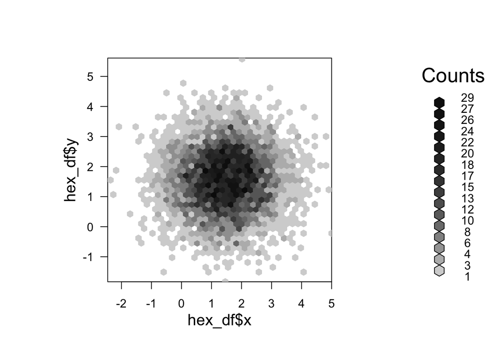

```r
library(tidyverse)
library(hexbin)

# Create data
hex_df <- tibble(x = rnorm(mean=1.5, 5000),
                 y = rnorm(mean=1.6, 5000))

# Make the plot
bin <- hexbin(hex_df$x, hex_df$y, xbins=40)
plot(bin, main="")
```

**`ggplot2`**

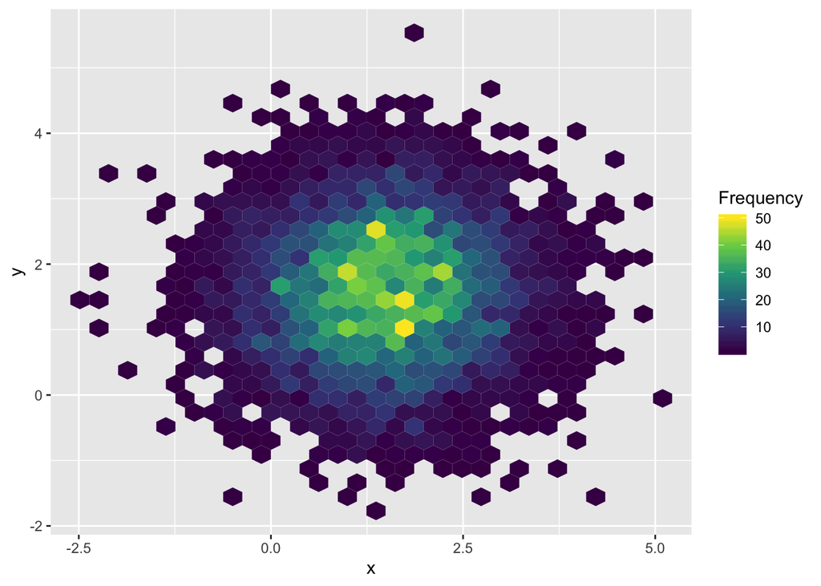

```r
# Make the ggplot
hex_df %>%
  ggplot(aes(x=x, y=y)) +
    geom_hex() +
    scale_fill_viridis_c(name="Frequency")
```

# 2 R 스티커

[Hexagon sticker in R](https://github.com/GuangchuangYu/hexSticker) 제작도구가 있어 [Tidyverse Korea](https://www.facebook.com/groups/tidyverse/) 미트업에 사용할 로고를 제작해본다.

[figure not shown]

KRUG 서울 R 스티커

```r
# install.packages("hexSticker")
library(hexSticker)
library(showtext)
font_add_google("Nanum Gothic", "NanumGothic")

p <- ggplot(aes(x = mpg, y = wt), data = mtcars) + geom_point()
p <- p + theme_void() + theme_transparent()

sticker("fig/Taegeuk.png", package="서울 KRUG", p_family="NanumGothic", p_size=6.5, p_color="#3d3838",
        s_x=1, s_y=.65, s_width=0.45, s_height=0.45,
         h_fill="#d9d9d9", h_color="#636363", spotlight = TRUE,
        filename="fig/KRUG_Seoul.png")
```

# 3 지도 → 육각형 [^1] [^2]

[`geogrid`: Turning geospatial polygons into regular or hexagonal grids](https://github.com/jbaileyh/geogrid) 팩키지에 내장된 영국 런던 데이터를 대상으로 원본 지도와 육각형으로 변환시킨 지도를 도식화해서 가능성을 타진한다.

```r
library(geogrid)
library(sf)
library(tmap)

input_file <- system.file("extdata", "london_LA.json", package = "geogrid")
original_shapes <- st_read(input_file) %>% st_set_crs(27700)
original_shapes$SNAME <- substr(original_shapes$NAME, 1, 4)
```

**원본 데이터**

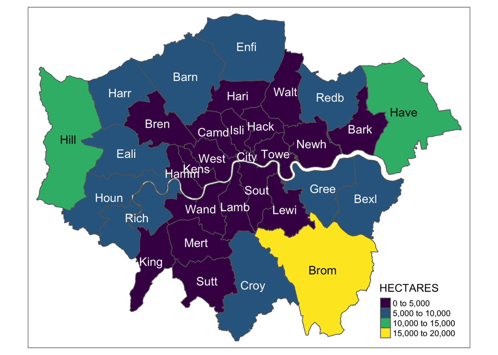

```r
raw_plot <- tm_shape(original_shapes) +
  tm_polygons("HECTARES", palette = "viridis") +
  tm_text("SNAME")
raw_plot
```

**육각형 변환 지도**

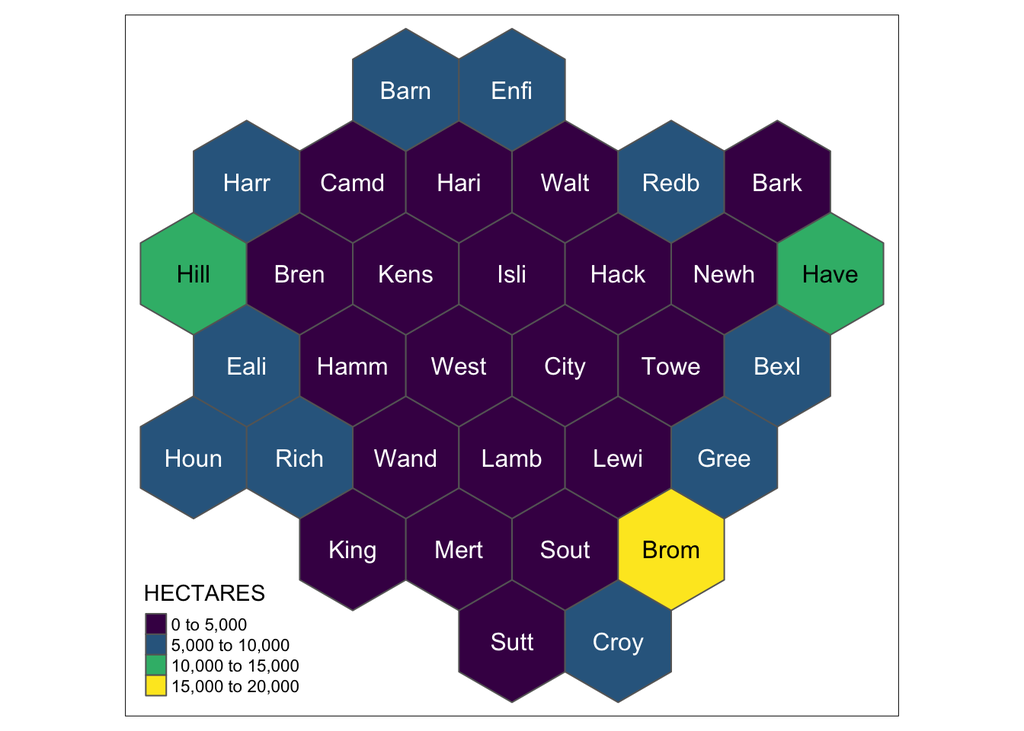

```r
## 변환
london_hex <- calculate_grid(shape = original_shapes, grid_type = "hexagonal", seed = 3)
london_hex_map <- assign_polygons(original_shapes, london_hex)

hex_plot <- tm_shape(london_hex_map) +
  tm_polygons("HECTARES", palette = "viridis") +
  tm_text("SNAME")

hex_plot
```

[^1]: [Simon Hailstone (2 November 2017), “Playing with the hexmapr and fingertipsR packages”](https://rpubs.com/Hailstone/326118)
[^2]: [`geogrid`: Turning geospatial polygons into regular or hexagonal grids](https://github.com/jbaileyh/geogrid)